# PH525.5x Section 2: Bioconductor Basics: GRanges and Biostrings

## Operating on GRanges

- Small set of ranges = intervals on chromosome
- Operations:
  - *reduce* - project all of the occupied into contiguous intervals and leaves empty parts with no coverage
  - *disjoin* - set of intervals / ranges generated by disjoin of set of ranges. Same occupancy as original GRanges object
    - Maximal complexity set of intervals where wherever there was an endpoint, we will not cross in a set of ranges.
  - *gap* - set xlim to show the regions that are never expressed. could be regarded as introns, spliced out. (gaps of exons are introns)
- Elaborate the set of intervals by turning it into a GRanges object by specifying seqnames and range information.
- Metadata that should be specified - strand information, genome, seqlengths, seqinfo
- How to pick out transcription start sites - plot overlapping genes. Resize with argument 1 to get down to one base from start. Gives us the addresses of start sites
- Finding promoters - interval of three bases upstream of bases upstream is regarded as a promoter. Use *flank* operation with argument 3 - gives us the locations of the upstream promoters. Use start=FALSE to indicate flank at the end of the interval rather than start.

## Finding Overlaps

- Example: finding genes that are close to reported binding sites and add some annotation to those genes
- HepG2 + GM12878 - reported binding sites for 2 cell lines
- Want to find the genes that are nearest to them. Instead of seperately, create a consensus GRanges which includes only sites that are common to both GRanges
- Function: *findOverlaps* uses query and subject - for each range, see if it appears in another range and return pair. Returns object of class *hits*. Only want the ones where there is a hit - use *queryHits* function and subset based on queryHits
- Extract just region information using *granges* function
- Show extraction of genes in next video, and matching of the regions in ERBS dataset to genes

```r
# load packages
library(GenomicFeatures)
library(GenomicRanges)
library(IRanges)
library(ERBS)

# load ESRRA ChIP data
data(HepG2)
data(GM12878)

# browseVignettes("GenomicRanges")

# find binding sites common to both HepG2 and GM12878
?findOverlaps
```

```
## Help on topic 'findOverlaps' was found in the following packages:
##
##   Package               Library
##   SummarizedExperiment
##                       /Library/Frameworks/R.framework/Versions/4.0/Resources/library
##   GenomicRanges         /Library/Frameworks/R.framework/Versions/4.0/Resources/library
##   GenomicAlignments     /Library/Frameworks/R.framework/Versions/4.0/Resources/library
##   IRanges               /Library/Frameworks/R.framework/Versions/4.0/Resources/library
##
##
## Using the first match ...
```

```r
# for each row in query, return overlapping row in subject
res = findOverlaps(HepG2, GM12878)
class(res)
```

```
## [1] "SortedByQueryHits"
## attr(,"package")
## [1] "S4Vectors"
```

```r
res
```

```
## Hits object with 75 hits and 0 metadata columns:
##        queryHits subjectHits
##        <integer>   <integer>
##    [1]         1          12
##    [2]         2          78
##    [3]         4         777
##    [4]         5           8
##    [5]         8          13
##    ...       ...         ...
##   [71]       285         621
##   [72]       287         174
##   [73]       291        1855
##   [74]       294         512
##   [75]       300         144
##   -------
##   queryLength: 303 / subjectLength: 1873
```

```r
# ranges from the query for which we found a hit in the subject
index = queryHits(res)
erbs = HepG2[index,]
erbs
```

```
## GRanges object with 75 ranges and 7 metadata columns:
##        seqnames              ranges strand |      name     score       col
##           <Rle>           <IRanges>  <Rle> | <numeric> <integer> <logical>
##    [1]     chr2   20335378-20335787      * |        NA         0      <NA>
##    [2]    chr20       328285-329145      * |        NA         0      <NA>
##    [3]    chr19     1244419-1245304      * |        NA         0      <NA>
##    [4]    chr11   64071828-64073069      * |        NA         0      <NA>
##    [5]     chr2   16938364-16938840      * |        NA         0      <NA>
##    ...      ...                 ...    ... .       ...       ...       ...
##   [71]    chr12 118558730-118559158      * |        NA         0      <NA>
##   [72]     chr1   35331750-35332300      * |        NA         0      <NA>
##   [73]     chr1   26146200-26147004      * |        NA         0      <NA>
##   [74]     chr6   44224657-44225693      * |        NA         0      <NA>
##   [75]     chr1 110198573-110199126      * |        NA         0      <NA>
##        signalValue    pValue      qValue      peak
##          <numeric> <numeric>   <numeric> <integer>
##    [1]      58.251    75.899 6.14371e-72       195
##    [2]      10.808    69.685 5.02806e-66       321
##    [3]      12.427    43.855 1.35976e-40       604
##    [4]      10.850    40.977 7.33386e-38       492
##    [5]      12.783    38.004 5.36029e-35       255
##    ...         ...       ...         ...       ...
##   [71]       8.292    10.294 8.59089e-09       195
##   [72]      10.458    10.233 9.81822e-09       341
##   [73]       5.742    10.176 1.10429e-08       337
##   [74]       3.525    10.102 1.29621e-08       838
##   [75]       7.929    10.047 1.44208e-08       197
##   -------
##   seqinfo: 93 sequences (1 circular) from hg19 genome
```

```r
# extract only the ranges
granges(erbs)
```

```
## GRanges object with 75 ranges and 0 metadata columns:
##        seqnames              ranges strand
##           <Rle>           <IRanges>  <Rle>
##    [1]     chr2   20335378-20335787      *
##    [2]    chr20       328285-329145      *
##    [3]    chr19     1244419-1245304      *
##    [4]    chr11   64071828-64073069      *
##    [5]     chr2   16938364-16938840      *
##    ...      ...                 ...    ...
##   [71]    chr12 118558730-118559158      *
##   [72]     chr1   35331750-35332300      *
##   [73]     chr1   26146200-26147004      *
##   [74]     chr6   44224657-44225693      *
##   [75]     chr1 110198573-110199126      *
##   -------
##   seqinfo: 93 sequences (1 circular) from hg19 genome
```

```r
erbs
```

```
## GRanges object with 75 ranges and 7 metadata columns:
##        seqnames              ranges strand |      name     score       col
##           <Rle>           <IRanges>  <Rle> | <numeric> <integer> <logical>
##    [1]     chr2   20335378-20335787      * |        NA         0      <NA>
##    [2]    chr20       328285-329145      * |        NA         0      <NA>
##    [3]    chr19     1244419-1245304      * |        NA         0      <NA>
##    [4]    chr11   64071828-64073069      * |        NA         0      <NA>
##    [5]     chr2   16938364-16938840      * |        NA         0      <NA>
##    ...      ...                 ...    ... .       ...       ...       ...
##   [71]    chr12 118558730-118559158      * |        NA         0      <NA>
##   [72]     chr1   35331750-35332300      * |        NA         0      <NA>
##   [73]     chr1   26146200-26147004      * |        NA         0      <NA>
##   [74]     chr6   44224657-44225693      * |        NA         0      <NA>
##   [75]     chr1 110198573-110199126      * |        NA         0      <NA>
##        signalValue    pValue      qValue      peak
##          <numeric> <numeric>   <numeric> <integer>
##    [1]      58.251    75.899 6.14371e-72       195
##    [2]      10.808    69.685 5.02806e-66       321
##    [3]      12.427    43.855 1.35976e-40       604
##    [4]      10.850    40.977 7.33386e-38       492
##    [5]      12.783    38.004 5.36029e-35       255
##    ...         ...       ...         ...       ...
##   [71]       8.292    10.294 8.59089e-09       195
##   [72]      10.458    10.233 9.81822e-09       341
##   [73]       5.742    10.176 1.10429e-08       337
##   [74]       3.525    10.102 1.29621e-08       838
##   [75]       7.929    10.047 1.44208e-08       197
##   -------
##   seqinfo: 93 sequences (1 circular) from hg19 genome
```

## Assessment: Finding Overlaps

```r
library(ERBS)
data(HepG2)
data(GM12878)
paste("17th region of HepG2 starts at:", start(granges(HepG2[17])))
```

```
## [1] "17th region of HepG2 starts at: 46528596"
```

```r
dtn <- distanceToNearest(HepG2[17], GM12878)
gm_idx <- subjectHits(dtn)
start_site <- start(GM12878[gm_idx])
distance_to_closest = mcols(dtn)$distance
paste("Start site of closest region to 17th region of HepG2: ", start_site)
```

```
## [1] "Start site of closest region to 17th region of HepG2:  46524762"
```

```r
paste("Distance between closest region to 17th region of HepG2: ", distance_to_closest)
```

```
## [1] "Distance between closest region to 17th region of HepG2:  2284"
```

```r
X <- vector(mode="integer", length=length(HepG2))
for(i in seq_along(HepG2)) {
     closest_region = distanceToNearest(HepG2[i], GM12878)
     distance = mcols(closest_region)$distance
     X[i] = distance
}
proportion_lt_2k_bp <- length(X[X < 2000]) / length(X)
paste("proportion of distances < 2000 bp: ", proportion_lt_2k_bp)
```

```
## [1] "proportion of distances < 2000 bp:  0.267326732673267"
```

## Genes as GRanges

- Mapping genes to binding sites
- Load Gene information from homo sapiens library and extract genes using function called **genes** - returns GRange

```r
library(Homo.sapiens)
library(ERBS)
ghs = genes(Homo.sapiens)
```

```
##   403 genes were dropped because they have exons located on both strands
##   of the same reference sequence or on more than one reference sequence,
##   so cannot be represented by a single genomic range.
##   Use 'single.strand.genes.only=FALSE' to get all the genes in a
##   GRangesList object, or use suppressMessages() to suppress this message.
```

```r
res = precede(erbs, ghs)
res
```

```
##  [1] 22817 16173 21772  7870 20199 22131 13257 20469 21943  8564 19061 15836
## [13] 21282  8959   278 14620  1657 22774 21746 10777 14568 20910  6626 12830
## [25]  9838 19991 21643 15740 12911 13326  8303 20834   934 10485 23027  4443
## [37]  6613 21335 21125 14508 15979  2693  4122  9485 17665 18376 17932  2696
## [49] 16990 16952 15735  9386  1642  3634  6037 20891 15062  1779  3316 11746
## [61] 12168 21689 22406 19979 14099 13558  3653  6077 21280  9705 13095  3322
## [73]  6343  1553  9552
```

```r
ghs[res[1:3]]
```

```
## GRanges object with 3 ranges and 1 metadata column:
##         seqnames            ranges strand |          GENEID
##            <Rle>         <IRanges>  <Rle> | <CharacterList>
##    9741     chr2 20232411-20251789      - |            9741
##   57761    chr20     361308-378203      + |           57761
##   90007    chr19   1248552-1259142      + |           90007
##   -------
##   seqinfo: 93 sequences (1 circular) from hg19 genome
```

- Start and end of genes - series of locations. Also have ID used by Homo sapiens database to match gene info across different databases
- Gene with ID 1 is in chromosome 19. Start defined in IRanges.
- **strand** tells you which of two DNA strands the gene is on. When gene expression happens, DNA opens up and code for gene could be in either strand.
- Movement of the transcription is going in a certain direction
- Large -> small if -, small -> large if -.
- Transcription start site - depends on strand information
- Function from **GenomicRanges** package called **precede** - tells you what is ahead of the transcription start site which varies depending on strand
- Finds entry and query closest to subject only when in front of.
- Moving towards report on which genes are closest to binding sites

## Assessment: Genes as GRanges

```r
library(Homo.sapiens)
ghs = genes(Homo.sapiens)
```

```
##   403 genes were dropped because they have exons located on both strands
##   of the same reference sequence or on more than one reference sequence,
##   so cannot be represented by a single genomic range.
##   Use 'single.strand.genes.only=FALSE' to get all the genes in a
##   GRangesList object, or use suppressMessages() to suppress this message.
```

```r
number_of_genes <- length(ghs)

paste("number of genes represented: ", number_of_genes)
```

```
## [1] "number of genes represented:  23056"
```

```r
chr_most_genes <- names(which.max(table(as.vector(seqnames(ghs)))))
paste("chromosome with most genes: ", chr_most_genes)
```

```
## [1] "chromosome with most genes:  chr1"
```

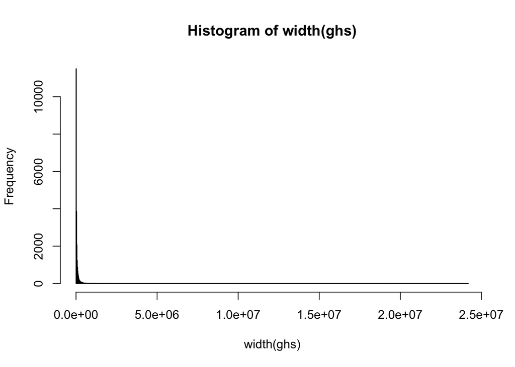

```r
hist(width(ghs), nc=1000)
```

```r
median_width <- median(width(ghs))

paste("median gene width: ", median_width)
```

```
## [1] "median gene width:  20115.5"
```

## Finding the Nearest Gene

- Compute distance between each binding site and corresponding gene found with precede, use **distance** function
- Takes two GRanges objects, and the genes we have found with precede
- We expect overlaps, however will not show up because we are requiring binding sites precede the genes

```r
library(Homo.sapiens)
ghs = genes(Homo.sapiens)
```

```
##   403 genes were dropped because they have exons located on both strands
##   of the same reference sequence or on more than one reference sequence,
##   so cannot be represented by a single genomic range.
##   Use 'single.strand.genes.only=FALSE' to get all the genes in a
##   GRangesList object, or use suppressMessages() to suppress this message.
```

```r
library(ERBS)
index = precede(erbs, ghs)
ghs[index[1:3]]
```

```
## GRanges object with 3 ranges and 1 metadata column:
##         seqnames            ranges strand |          GENEID
##            <Rle>         <IRanges>  <Rle> | <CharacterList>
##    9741     chr2 20232411-20251789      - |            9741
##   57761    chr20     361308-378203      + |           57761
##   90007    chr19   1248552-1259142      + |           90007
##   -------
##   seqinfo: 93 sequences (1 circular) from hg19 genome
```

```r
erbs[1:3]
```

```
## GRanges object with 3 ranges and 7 metadata columns:
##       seqnames            ranges strand |      name     score       col
##          <Rle>         <IRanges>  <Rle> | <numeric> <integer> <logical>
##   [1]     chr2 20335378-20335787      * |        NA         0      <NA>
##   [2]    chr20     328285-329145      * |        NA         0      <NA>
##   [3]    chr19   1244419-1245304      * |        NA         0      <NA>
##       signalValue    pValue      qValue      peak
##         <numeric> <numeric>   <numeric> <integer>
##   [1]      58.251    75.899 6.14371e-72       195
##   [2]      10.808    69.685 5.02806e-66       321
##   [3]      12.427    43.855 1.35976e-40       604
##   -------
##   seqinfo: 93 sequences (1 circular) from hg19 genome
```

```r
distance(erbs, ghs[index])
```

```
##  [1]   83588   32162    3247   12490   91229  125579   95887  203084   26140
## [10]    4342 1158347   30950   82008   20658   32087   19444   74549    5110
## [19]   14252   48739   11043   29669   24061   22090 1989458   77873  343959
## [28]   30283   14601   48298   23414    5533   23832  962904    4678   12616
## [37]   13959  141321   75543   19992   25200   29955   26967   22447   82062
## [46]   12918     880   67725  177905   72543   26399   41808     676  437226
## [55]  270972  105665   60815   82132   40245   14666   74833  127391   10252
## [64]  140320   14696   39814    5507     444  195514   72907   14711    6332
## [73]  201266    2634   31291
```

```r
tssgr = resize(ghs, 1) # shrink down to one going in direction towards transcription start site, aware of strand
tssgr
```

```
## GRanges object with 23056 ranges and 1 metadata column:
##         seqnames    ranges strand |          GENEID
##            <Rle> <IRanges>  <Rle> | <CharacterList>
##       1    chr19  58874214      - |               1
##      10     chr8  18248755      + |              10
##     100    chr20  43280376      - |             100
##    1000    chr18  25757445      - |            1000
##   10000     chr1 244006886      - |           10000
##     ...      ...       ...    ... .             ...
##    9991     chr9 115095944      - |            9991
##    9992    chr21  35736323      + |            9992
##    9993    chr22  19109967      - |            9993
##    9994     chr6  90539619      + |            9994
##    9997    chr22  50964905      - |            9997
##   -------
##   seqinfo: 93 sequences (1 circular) from hg19 genome
```

```r
d=distanceToNearest(erbs, tssgr)

queryHits(d)
```

```
##  [1]  1  2  3  4  5  6  7  8  9 10 11 12 13 14 15 16 17 18 19 20 21 22 23 24 25
## [26] 26 27 28 29 30 31 32 33 34 35 36 37 38 39 40 41 42 43 44 45 46 47 48 49 50
## [51] 51 52 53 54 55 56 57 58 59 60 61 62 63 64 65 66 67 68 69 70 71 72 73 74 75
```

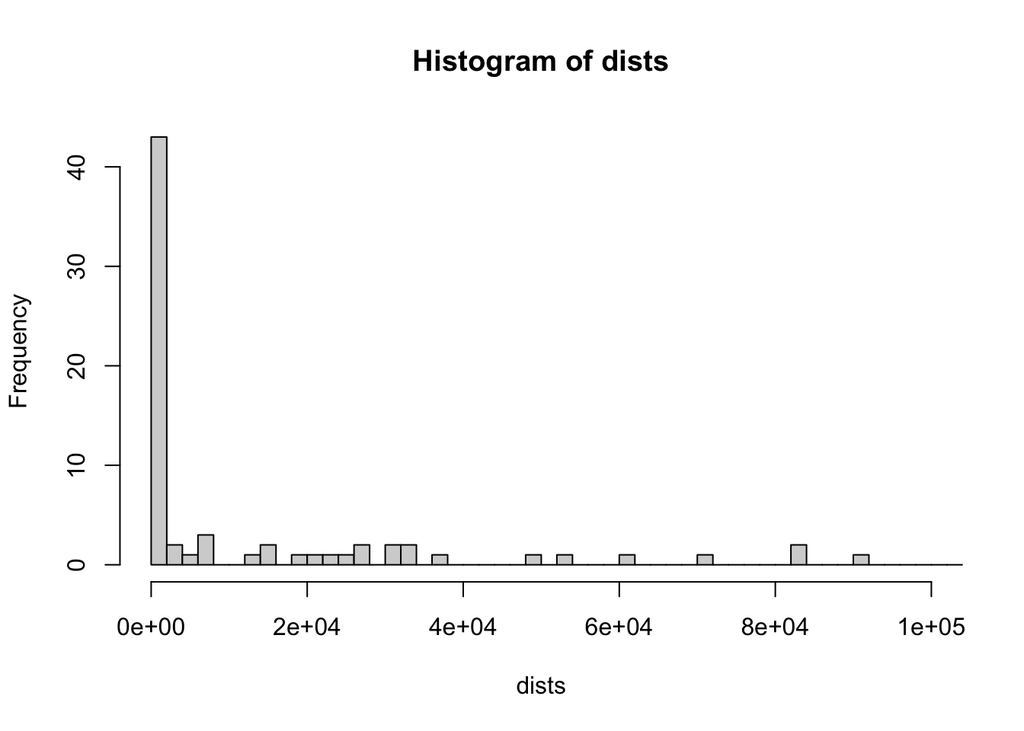

```r
dists = values(d)$distance
hist(dists,nc=1000,xlim=c(0,100000))
```

```r
index = subjectHits(d)[dists < 1000]
index
```

```
##  [1] 19883  6316 18488 14325  9348 19622 19678 16536  4171 13017 21240 22438
## [13] 10812 20840 13796  8334  2185  2917 16265  6286 21787 14490 17932 13607
## [25]  3681  1642 21117  2204 14339 12775 13722 16883 19605 15633  7235  6077
## [37] 14605  3119 15380 10503  9555
```

- define another distance: ask for each binding site, find the transcription start site that is closest
- For each of our binding sites, find the closest transcription start site using **distanceToNearest**. Finds distance to nearest given query and subject
- Now, we have zeros because there is overlap. Output is a **hits** object. Need to use **queryHits** rather than subsetting.
- For distance, use **values** function to extract columns and grab distance
- Index of genes that are closest using **subjectHits**
- Find genes that are closer than 1k to binding sites
- Use genes that were found to be close, and get further information

## Annotating Genes

- Use **select** function to query Homo sapiens database
- Need to give: key, columns we want to look at, key type
- Example of going from ranges to list of interesting genes

```r
library(Homo.sapiens)
library(ERBS)
ghs = genes(Homo.sapiens)
```

```
##   403 genes were dropped because they have exons located on both strands
##   of the same reference sequence or on more than one reference sequence,
##   so cannot be represented by a single genomic range.
##   Use 'single.strand.genes.only=FALSE' to get all the genes in a
##   GRangesList object, or use suppressMessages() to suppress this message.
```

```r
tssgr = resize(ghs, 1) # shrink down to one going in direction towards transcription start site, aware of strand
d=distanceToNearest(erbs, tssgr)
dists = values(d)$distance
index = subjectHits(d)[dists < 1000]
tssgr[index,]
```

```
## GRanges object with 41 ranges and 1 metadata column:
##          seqnames    ranges strand |          GENEID
##             <Rle> <IRanges>  <Rle> | <CharacterList>
##    80023    chr20    327370      + |           80023
##     2101    chr11  64073044      + |            2101
##     7086     chr3  53290130      - |            7086
##     5478     chr7  44836241      + |            5478
##   286262     chr9 140095163      - |          286262
##      ...      ...       ...    ... .             ...
##    55090    chr17  17380300      + |           55090
##    11165     chr6  34360457      - |           11165
##    56181     chr1  26146397      + |           56181
##   347734     chr6  44225283      - |          347734
##     2948     chr1 110198698      + |            2948
##   -------
##   seqinfo: 93 sequences (1 circular) from hg19 genome
```

```r
keytypes(Homo.sapiens)
```

```
##  [1] "ACCNUM"       "ALIAS"        "CDSID"        "CDSNAME"      "DEFINITION"
##  [6] "ENSEMBL"      "ENSEMBLPROT"  "ENSEMBLTRANS" "ENTREZID"     "ENZYME"
## [11] "EVIDENCE"     "EVIDENCEALL"  "EXONID"       "EXONNAME"     "GENEID"
## [16] "GENENAME"     "GO"           "GOALL"        "GOID"         "IPI"
## [21] "MAP"          "OMIM"         "ONTOLOGY"     "ONTOLOGYALL"  "PATH"
## [26] "PFAM"         "PMID"         "PROSITE"      "REFSEQ"       "SYMBOL"
## [31] "TERM"         "TXID"         "TXNAME"       "UCSCKG"       "UNIGENE"
## [36] "UNIPROT"
```

```r
keys = as.character(values(tssgr[index])$GENEID)
columns(Homo.sapiens)
```

```
##  [1] "ACCNUM"       "ALIAS"        "CDSCHROM"     "CDSEND"       "CDSID"
##  [6] "CDSNAME"      "CDSSTART"     "CDSSTRAND"    "DEFINITION"   "ENSEMBL"
## [11] "ENSEMBLPROT"  "ENSEMBLTRANS" "ENTREZID"     "ENZYME"       "EVIDENCE"
## [16] "EVIDENCEALL"  "EXONCHROM"    "EXONEND"      "EXONID"       "EXONNAME"
## [21] "EXONRANK"     "EXONSTART"    "EXONSTRAND"   "GENEID"       "GENENAME"
## [26] "GO"           "GOALL"        "GOID"         "IPI"          "MAP"
## [31] "OMIM"         "ONTOLOGY"     "ONTOLOGYALL"  "PATH"         "PFAM"
## [36] "PMID"         "PROSITE"      "REFSEQ"       "SYMBOL"       "TERM"
## [41] "TXCHROM"      "TXEND"        "TXID"         "TXNAME"       "TXSTART"
## [46] "TXSTRAND"     "TXTYPE"       "UCSCKG"       "UNIGENE"      "UNIPROT"
```

```r
res = select(Homo.sapiens, keys = keys,
             columns = c("SYMBOL", "GENENAME"), keytype="GENEID")
res[1:2,]
```

```
##   GENEID                        GENENAME SYMBOL
## 1  80023                     neurensin 2  NRSN2
## 2   2101 estrogen related receptor alpha  ESRRA
```

## Assessment: Finding and getting annotation for closest gene

- Find the closest genes to some of our binding sites - use consensus set of regions

```r
library(ERBS)
data(HepG2)
data(GM12878)
res = findOverlaps(HepG2,GM12878)
erbs = HepG2[queryHits(res)]
erbs = granges(erbs)

erbs2= intersect(HepG2,GM12878)

erbs
```

```
## GRanges object with 75 ranges and 0 metadata columns:
##        seqnames              ranges strand
##           <Rle>           <IRanges>  <Rle>
##    [1]     chr2   20335378-20335787      *
##    [2]    chr20       328285-329145      *
##    [3]    chr19     1244419-1245304      *
##    [4]    chr11   64071828-64073069      *
##    [5]     chr2   16938364-16938840      *
##    ...      ...                 ...    ...
##   [71]    chr12 118558730-118559158      *
##   [72]     chr1   35331750-35332300      *
##   [73]     chr1   26146200-26147004      *
##   [74]     chr6   44224657-44225693      *
##   [75]     chr1 110198573-110199126      *
##   -------
##   seqinfo: 93 sequences (1 circular) from hg19 genome
```

```r
erbs2
```

```
## GRanges object with 75 ranges and 0 metadata columns:
##        seqnames              ranges strand
##           <Rle>           <IRanges>  <Rle>
##    [1]     chr1   16339152-16339862      *
##    [2]     chr1   26146200-26147004      *
##    [3]     chr1   32879507-32879907      *
##    [4]     chr1   35331750-35332300      *
##    [5]     chr1 102900017-102900356      *
##    ...      ...                 ...    ...
##   [71]    chr20   62586998-62587997      *
##   [72]    chr22   29977062-29977454      *
##   [73]     chrX     1510388-1511745      *
##   [74]     chrX   26801642-26802021      *
##   [75]     chrX   54466501-54466956      *
##   -------
##   seqinfo: 93 sequences (1 circular) from hg19 genome
```

```r
library(Homo.sapiens)
ghs = genes(Homo.sapiens)
```

```
##   403 genes were dropped because they have exons located on both strands
##   of the same reference sequence or on more than one reference sequence,
##   so cannot be represented by a single genomic range.
##   Use 'single.strand.genes.only=FALSE' to get all the genes in a
##   GRangesList object, or use suppressMessages() to suppress this message.
```

```r
transcription_start_site=resize(ghs["100113402"], 1)
paste("transcription start site for gene id 100113402: ", transcription_start_site)
```

```
## [1] "transcription start site for gene id 100113402:  chr16:70563402:+"
```

```r
library(ERBS)
data(HepG2)
data(GM12878)
res = findOverlaps(HepG2,GM12878)
erbs = HepG2[queryHits(res)]
erbs = granges(erbs)
index = nearest(erbs[4], tssgr)
index
```

```
## [1] 6316
```

```r
gene_id <- names(tssgr[index,]$GENEID)

paste("gene id with TSS closest to 4th region of erbs: ", gene_id)
```

```
## [1] "gene id with TSS closest to 4th region of erbs:  2101"
```

```r
keys = as.character(values(tssgr[index])$GENEID)
symbol_of_gene <- select(Homo.sapiens, keys=keys, columns=c("SYMBOL"), keytype="GENEID")
paste("Symbol of gene id: ", symbol_of_gene$SYMBOL)
```

```
## [1] "Symbol of gene id:  ESRRA"
```

## DNAString objects

- **Biostrings** package - efficient handling of DNA, RNA and amino acide sequences in Bioconductor
- Classes for representing individual molecular sequences and optimized functions for performing operations of sequences and sequence sets
- DNA sequences represented as **DNAString** objects. Also **RNAString** and **AAString** classes for representing RNA and protein sequences
- Collectively referred to as **XString** objects

```r
library(Biostrings)
dna <- DNAString("TCGAGCAAT")
dna
```

```
## 9-letter DNAString object
## seq: TCGAGCAAT
```

```r
length(dna) # number of bases in a DNAString
```

```
## [1] 9
```

```r
try(DNAString("JQX")) # Invalid bases
```

```
## Error in .Call2("new_XString_from_CHARACTER", class(x0), string, start,  :
##   key 74 (char 'J') not in lookup table
```

```r
try(DNAString("NNNACGCGC-TTA-CGGGCTANN")) # unknowns and gaps
```

```
## 23-letter DNAString object
## seq: NNNACGCGC-TTA-CGGGCTANN
```

```r
dna[4:6] # substring
```

```
## 3-letter DNAString object
## seq: AGC
```

```r
as.character(dna) # convert DNAString to character
```

```
## [1] "TCGAGCAAT"
```

## DNAStringSet objects

- Grouping sets of biostrings in order to operate on them together - **XStringSets**

```r
set1 <- DNAStringSet(c("TCA", "AAATCG", "ACGTGCCTA", "CGCGCA", "GTT", "TCA"))
set1
```

```
## DNAStringSet object of length 6:
##     width seq
## [1]     3 TCA
## [2]     6 AAATCG
## [3]     9 ACGTGCCTA
## [4]     6 CGCGCA
## [5]     3 GTT
## [6]     3 TCA
```

```r
set1[2:3] # extract subset of sequences
```

```
## DNAStringSet object of length 2:
##     width seq
## [1]     6 AAATCG
## [2]     9 ACGTGCCTA
```

```r
set1[[4]] # extract one sequence as a single DNAString
```

```
## 6-letter DNAString object
## seq: CGCGCA
```

```r
length(set1) # number of DNAStrings in set
```

```
## [1] 6
```

```r
width(set1) # size of each DNAString
```

```
## [1] 3 6 9 6 3 3
```

```r
duplicated(set1) # detect which sequences are duplicated
```

```
## [1] FALSE FALSE FALSE FALSE FALSE  TRUE
```

```r
unique(set1) # keep only unique sequences
```

```
## DNAStringSet object of length 5:
##     width seq
## [1]     3 TCA
## [2]     6 AAATCG
## [3]     9 ACGTGCCTA
## [4]     6 CGCGCA
## [5]     3 GTT
```

```r
sort(set1)
```

```
## DNAStringSet object of length 6:
##     width seq
## [1]     6 AAATCG
## [2]     9 ACGTGCCTA
## [3]     6 CGCGCA
## [4]     3 GTT
## [5]     3 TCA
## [6]     3 TCA
```

## Operations on DNAStrings

- Walkthrough common operations

```r
dna_seq <- DNAString("ATCGCGCGCGGCTCTTTTAAAAAAACGCTACTACCATGTGTGTCTATC")
letterFrequency(dna_seq, "A") # count A in sequence
```

```
##  A
## 12
```

```r
letterFrequency(dna_seq, "GC") # count G or C in sequence
```

```
## G|C
##  22
```

```r
dinucleotideFrequency(dna_seq) # frequencies of all dinucleotides
```

```
## AA AC AG AT CA CC CG CT GA GC GG GT TA TC TG TT
##  6  3  0  3  1  1  5  5  0  5  1  3  4  4  3  3
```

```r
trinucleotideFrequency(dna_seq) # frequencies of all trinucleotides
```

```
## AAA AAC AAG AAT ACA ACC ACG ACT AGA AGC AGG AGT ATA ATC ATG ATT CAA CAC CAG CAT
##   5   1   0   0   0   1   1   1   0   0   0   0   0   2   1   0   0   0   0   1
## CCA CCC CCG CCT CGA CGC CGG CGT CTA CTC CTG CTT GAA GAC GAG GAT GCA GCC GCG GCT
##   1   0   0   0   0   4   1   0   3   1   0   1   0   0   0   0   0   0   3   2
## GGA GGC GGG GGT GTA GTC GTG GTT TAA TAC TAG TAT TCA TCC TCG TCT TGA TGC TGG TGT
##   0   1   0   0   0   1   2   0   1   2   0   1   0   0   1   2   0   0   0   3
## TTA TTC TTG TTT
##   1   0   0   2
```

```r
# convert DNAStrings

reverseComplement(dna_seq) # find reverse complement
```

```
## 48-letter DNAString object
## seq: GATAGACACACATGGTAGTAGCGTTTTTTTAAAAGAGCCGCGCGCGAT
```

```r
translate(dna_seq) # amino acid translation
```

```
## 16-letter AAString object
## seq: IARGSFKKTLLPCVSI
```

## Matching and Counting with Biostrings

- Finding all locations or counting matches of a pattern in a molecular seqeunce are common tasks
- **Biostrings** package includes fast function for pattern matching and counting on **XString** and **XStringSet** objects.

```r
# count and match on individual Biostrings
dna_seq <- DNAString("ATCGCGCGCGGCTCTTTTAAAAAAACGCTACTACCATGTGTGTCTATC")
dna_seq
```

```
## 48-letter DNAString object
## seq: ATCGCGCGCGGCTCTTTTAAAAAAACGCTACTACCATGTGTGTCTATC
```

```r
countPattern("CG", dna_seq) # pattern CG occurs 5x
```

```
## [1] 5
```

```r
matchPattern("CG", dna_seq) # locations of the pattern
```

```
## Views on a 48-letter DNAString subject
## subject: ATCGCGCGCGGCTCTTTTAAAAAAACGCTACTACCATGTGTGTCTATC
## views:
##       start end width
##   [1]     3   4     2 [CG]
##   [2]     5   6     2 [CG]
##   [3]     7   8     2 [CG]
##   [4]     9  10     2 [CG]
##   [5]    26  27     2 [CG]
```

```r
start(matchPattern("CG", dna_seq)) # start locations of the pattern
```

```
## [1]  3  5  7  9 26
```

```r
matchPattern("CTCTTTTAAAAAAACGCTACTACCATGTGT", dna_seq) # match pattern of any length
```

```
## Views on a 48-letter DNAString subject
## subject: ATCGCGCGCGGCTCTTTTAAAAAAACGCTACTACCATGTGTGTCTATC
## views:
##       start end width
##   [1]    12  41    30 [CTCTTTTAAAAAAACGCTACTACCATGTGT]
```

```r
# check for pattern and its reverse complement
countPattern("TAG", dna_seq)
```

```
## [1] 0
```

```r
countPattern(reverseComplement(DNAString("TAG")), dna_seq)
```

```
## [1] 3
```

```r
# count and match on sets of BioStrings
set2 <- DNAStringSet(c("AACCGGTTTCGA", "CATGCTGCTACA", "CGATCGCGCCGG", "TACAACCGTACA"))
set2
```

```
## DNAStringSet object of length 4:
##     width seq
## [1]    12 AACCGGTTTCGA
## [2]    12 CATGCTGCTACA
## [3]    12 CGATCGCGCCGG
## [4]    12 TACAACCGTACA
```

```r
vcountPattern("CG", set2) # counts for entire DNAStringSet
```

```
## [1] 2 0 4 1
```

```r
vmatchPattern("CG", set2)
```

```
## MIndex object of length 4
## [[1]]
## IRanges object with 2 ranges and 0 metadata columns:
##           start       end     width
##       <integer> <integer> <integer>
##   [1]         4         5         2
##   [2]        10        11         2
##
## [[2]]
## IRanges object with 0 ranges and 0 metadata columns:
##        start       end     width
##    <integer> <integer> <integer>
##
## [[3]]
## IRanges object with 4 ranges and 0 metadata columns:
##           start       end     width
##       <integer> <integer> <integer>
##   [1]         1         2         2
##   [2]         5         6         2
##   [3]         7         8         2
##   [4]        10        11         2
##
## [[4]]
## IRanges object with 1 range and 0 metadata columns:
##           start       end     width
##       <integer> <integer> <integer>
##   [1]         7         8         2
```

```r
vmatchPattern("CG", set2)[[1]] # access matches for first element of DNAStringSet
```

```
## IRanges object with 2 ranges and 0 metadata columns:
##           start       end     width
##       <integer> <integer> <integer>
##   [1]         4         5         2
##   [2]        10        11         2
```

## Assessment: Biostrings

- eco seqeuence: short excerpt from E. coli K12 strain genome
- detect and analyze peptide encoded by genome fragment

```r
eco <- DNAString("GGTTTCACCGCCGGTAATGAAAAAGGCGAACTGGTGGTGCTTGGACGCAACGGTTCCGACTACTCTGCTGCGGTGCTGGCTGCCTGTTTACGCGCCGATTGTTGCGAGATTTGGACGGACGTTGACGGGGTCTATACCTGCGACCCGCGTCAGGTGCCCGATGCGAGGTTGTTGAAGTCGA")
eco
```

```
## 181-letter DNAString object
## seq: GGTTTCACCGCCGGTAATGAAAAAGGCGAACTGGTG...CGCGTCAGGTGCCCGATGCGAGGTTGTTGAAGTCGA
```

```r
number_of_bases=length(eco)
paste("number of bases in eco: ", number_of_bases)
```

```
## [1] "number of bases in eco:  181"
```

```r
count_atg <- countPattern("ATG", eco)
paste("Potential start codon in eco sequence: ", count_atg)
```

```
## [1] "Potential start codon in eco sequence:  2"
```

```r
start_location_first_atg <- start(matchPattern("ATG", eco))
paste("Start location of the first ATG trinucleotide: ", start_location_first_atg[1])
```

```
## [1] "Start location of the first ATG trinucleotide:  17"
```

```r
subset_from_start_location <- eco[start_location_first_atg[1]:length(eco)]
translated <- translate(subset_from_start_location)
paste("Length of resulting subset translated into amino acid: ", length(translated))
```

```
## [1] "Length of resulting subset translated into amino acid:  55"
```

```r
location_of_stop_codon <- start(matchPattern("*", translated))
paste("Location of stop codon in AAString: ", location_of_stop_codon)
```

```
## [1] "Location of stop codon in AAString:  53"
```

```r
subset_before_stop_codon <- translated[1:location_of_stop_codon-1]
subset_before_stop_codon
```

```
## 52-letter AAString object
## seq: MKKANWWCLDATVPTTLLRCWLPVYAPIVARFGRTLTGSIPATRVRCPMRGC
```

```r
num_amino_acids <- length(subset_before_stop_codon)
paste("Number of amino acids in AAString before stop codon: ", num_amino_acids)
```

```
## [1] "Number of amino acids in AAString before stop codon:  52"
```

```r
paste("Sequence: ", subset_before_stop_codon)
```

```
## [1] "Sequence:  MKKANWWCLDATVPTTLLRCWLPVYAPIVARFGRTLTGSIPATRVRCPMRGC"
```

```r
positive_charge <- sum(countPattern("K", subset_before_stop_codon), countPattern("H", subset_before_stop_codon),
                       countPattern("R", subset_before_stop_codon))
paste("Number of positively charged amino acids: ", positive_charge)
```

```
## [1] "Number of positively charged amino acids:  8"
```

```r
negative_charge <- sum(countPattern("D", subset_before_stop_codon), countPattern("E", subset_before_stop_codon))
paste("Number of negatively charged amino acids: ", negative_charge)
```

```
## [1] "Number of negatively charged amino acids:  1"
```

```r
net_charge <- positive_charge - negative_charge
paste("Net charge of peptide at pH 7: ", net_charge)
```

```
## [1] "Net charge of peptide at pH 7:  7"
```

## Getting the sequence of Regions

- How to use the whole reference genomic sequence of Homo Sapiens to look at the content of binding sites for the estrogen receptor
- HepG2 is a GRanges telling us where ChIP-seq experiments have identified locations where the estrogen receptor nuclear protein will bind
- Check the occurrence of certain short sequence called “binding motif” in the genomic sequence over which binding peaks are found
- Look up sequence of some genomic feature: match against the DNAString
- **getSeq** function from BioStrings package
- would not in practice use fixed string motif, would use matrix representation or model for this indicating variation in some of the bases
- MotifDb package includes models for binding motifs
- Would also not do direct pattern matching of this type, but something reflecting the probabilistic structure of the binding process. See: program MEME and FIMO
- Summary: we have genomic sequence for all chromosomes of homo sapeins. We have binding peak addresses in a GRanges. We can use getSeq to get the sequence content of the ranges, and search for motifs in those sequences to confirm biological plausibility

```r
library(ERBS)
data(HepG2)
library(BSgenome.Hsapiens.UCSC.hg19) # reference build that was used for labeling of peaks
Hsapiens # metadata about the construction of data object
```

```
## Human genome:
## # organism: Homo sapiens (Human)
## # genome: hg19
## # provider: UCSC
## # release date: June 2013
## # 298 sequences:
## #   chr1                  chr2                  chr3
## #   chr4                  chr5                  chr6
## #   chr7                  chr8                  chr9
## #   chr10                 chr11                 chr12
## #   chr13                 chr14                 chr15
## #   ...                   ...                   ...
## #   chr19_gl949749_alt    chr19_gl949750_alt    chr19_gl949751_alt
## #   chr19_gl949752_alt    chr19_gl949753_alt    chr20_gl383577_alt
## #   chr21_gl383578_alt    chr21_gl383579_alt    chr21_gl383580_alt
## #   chr21_gl383581_alt    chr22_gl383582_alt    chr22_gl383583_alt
## #   chr22_kb663609_alt
## # (use 'seqnames()' to see all the sequence names, use the '$' or '[[' operator
## # to access a given sequence)
```

```r
ch17 <- Hsapiens$chr17 # sequence of chromosome 17
class(Hsapiens)
```

```
## [1] "BSgenome"
## attr(,"package")
## [1] "BSgenome"
```

```r
hepseq = getSeq(Hsapiens, HepG2) # dna string set of length hepg2 (303), one for each of binding peaks
hepseq
```

```
## DNAStringSet object of length 303:
##       width seq
##   [1]   410 GAGACAGGGTTTCACCATGTTGGCCAGGCTGGT...CTTCCAGGAAGCAGAAATGTTCAAGGACTCTC
##   [2]   861 TGGGAAGGACACAACTGAATGAGGCTGTGCAGA...GCAGAACCTCCAACCGTGTGTGTGTGTGTGTG
##   [3]  1156 GACACCTGCCACCCCGGACCCCACAGAATGGGC...CTTCGTGTCTGCTTTCTTATGTGTTTTTGTTT
##   [4]   886 GTGAAGGCCCTGGAGTAGGCGGTGCGTACCCGG...GTGTTTTTGGCACCTCCGTGGGCACCTAGGCT
##   [5]  1242 CATCCTCCACCTTAACACTCAGCACCCTTAGAG...TTTGTGTCCTACAAGCAGCCGGCGGCGCCGCC
##   ...   ... ...
## [299]   671 CACTGGAGCTGGTGAAACAGGTAGTGAGTTGAT...TCATCTAGGGAGGCATGCAGCCCTCACCTGAG
## [300]   554 TCCGGAGAAGAAGAAACGGGGGAAGAACTTTTC...GTGCCGAGCGGCTGGGGACCGGCTCTAGGGAC
## [301]   418 CCACACCTGGAGCCAGTCTCAATGGCTCCCTGA...CATGAATGGTTGGAGACCAGGGGAGTTCTGTG
## [302]   456 TGATGACATTTCTCAAGGATTAAGAAAAAGAGA...CCTGCACCCATTTTGGTTTTGCTGTAGGGCCT
## [303]   348 TCCAAAGCAGACACTCCAGGACACCTGATTCTC...TTCTTTTTTTGAGACGGAGTCTCGTTCTGTCG
```

```r
width(HepG2[1:5])
```

```
## [1]  410  861 1156  886 1242
```

```r
rhepseq = getSeq(Hsapiens, shift(HepG2, 2500)) # collection of DNA strings which have no principled relationship to binding peaks
rhepseq
```

```
## DNAStringSet object of length 303:
##       width seq
##   [1]   410 CTGCAGCCAGAAAGCAGGTCAGGGCTTGCCTGA...TTTGAAGAAATACAGTACCAGGGCATCATAGA
##   [2]   861 ACCTGCTCTGTCAGCATGGCGAAACCCTTTCTC...TGTAATCCCATCATTTTGGGAGGCCAAGGTGG
##   [3]  1156 AGGGGCATGGCCCACGGGCCCACCGTGGGGTTG...TGTATGCACTCTAGTTTTTATTATTAAACCAA
##   [4]   886 TCCCGGGTTCGAGCAATGCTCCCGCCTCAGCCT...AACCAGGACCATCCTCAAAAAGCCGACGGGGA
##   [5]  1242 AAGGTTGCCTGGGGGCTACGGTTACCCTGCTCC...ATTTTTAGTAGAGACGACGTTTCACCATGTCG
##   ...   ... ...
## [299]   671 GAATGACAAGTGATGGCGCAACCCGCCCAGCTG...CATCGCCCCCCAGACCGTCCACACGGCCACGT
## [300]   554 TTTCAACTTCTTTCTCTGAGCTCCTTTAGTTCT...AGCCCACACATTCTTGGCCTTCTGCAGATCAC
## [301]   418 ATGGTGAAACCCCATCTCTACTAAAAATACAAA...ATGATATACTAAAAATGGGTAAATTTTGTGAT
## [302]   456 TGCAGGGCAGACGCAGGGACCCTGGTCCAGCGG...AGGCAAGCAGTGAAGACAGAGGGGTGGCCCGA
## [303]   348 CATTCAGTAAATATCTATTGGGTCCCTTTGTTT...ACTACTTGTTTTAAAAGTAGTGCATTAATTAA
```

```r
mot = "TCAAGGTCA" # one representation of binding motif for ER protein

sum(vcountPattern(mot, hepseq)) # count of times the motif occurs
```

```
## [1] 20
```

```r
sum(vcountPattern(mot, reverseComplement(hepseq))) # match reverse compliment of hepseq
```

```
## [1] 35
```

```r
total_sum = sum(vcountPattern(mot, hepseq), vcountPattern(mot, reverseComplement(hepseq)))
total_sum
```

```
## [1] 55
```

```r
 # compare with the randomly selected equal length collection of DNA string
sum(vcountPattern(mot, rhepseq), vcountPattern(mot, reverseComplement(rhepseq)))
```

```
## [1] 6
```

## Assessment: Getting sequences

```r
library(ERBS)
library(GenomicRanges)
data(HepG2)
data(GM12878)
res = findOverlaps(HepG2,GM12878)
erbs = HepG2[queryHits(res)]
erbs = granges(erbs)

library(BSgenome.Hsapiens.UCSC.hg19)

hepseq = getSeq(Hsapiens, erbs)
gc_content <- (vcountPattern("C", hepseq) + vcountPattern("G", hepseq)) / width(hepseq)
gc_content
```

```
##  [1] 0.5682927 0.6527294 0.6805869 0.6497585 0.5157233 0.6148282 0.5352324
##  [8] 0.6859903 0.5423112 0.7356322 0.7334315 0.6431227 0.5959596 0.5000000
## [15] 0.5495890 0.4837905 0.4400871 0.6785714 0.6476898 0.6560150 0.7123711
## [22] 0.4853420 0.6709677 0.6157761 0.7180157 0.5075000 0.5202864 0.6960258
## [29] 0.6346968 0.5369863 0.6646778 0.7694175 0.6868009 0.4736842 0.6095238
## [36] 0.5921502 0.6909976 0.6898551 0.6875834 0.6406460 0.5083799 0.6853193
## [43] 0.6818727 0.6701389 0.5657895 0.7370000 0.7053763 0.6149068 0.5191257
## [50] 0.6510417 0.6104418 0.7107558 0.6117886 0.5088235 0.6574713 0.7442197
## [57] 0.6466019 0.7216495 0.7353579 0.5679172 0.6602086 0.6218487 0.5285935
## [64] 0.6358930 0.6938776 0.6601307 0.6694796 0.6525680 0.6888889 0.7030129
## [71] 0.4778555 0.6860254 0.7130435 0.7087753 0.6552347
```

```r
paste("median gc-content: ", median(gc_content))
```

```
## [1] "median gc-content:  0.652567975830816"
```

```r
control_set <- getSeq(Hsapiens, shift(erbs, 10000))

gc_content_control <- (vcountPattern("C", control_set) + vcountPattern("G", control_set)) / width(control_set)
paste("median gc-content of control: ", median(gc_content_control))
```

```
## [1] "median gc-content of control:  0.486017357762777"
```

## Assessment: GRanges and Biostrings

```r
library(GenomicRanges)
library(Biostrings)
library(Homo.sapiens)
library(BSgenome.Hsapiens.UCSC.hg19)
library(ERBS)

library(Homo.sapiens)
g <- genes(Homo.sapiens)
```

```
##   403 genes were dropped because they have exons located on both strands
##   of the same reference sequence or on more than one reference sequence,
##   so cannot be represented by a single genomic range.
##   Use 'single.strand.genes.only=FALSE' to get all the genes in a
##   GRangesList object, or use suppressMessages() to suppress this message.
```

```r
unique_seqlevels <- length(unique(seqlevels(g)))
num_genes <- length(g)
paste("number of genes in build: ", num_genes)
```

```
## [1] "number of genes in build:  23056"
```

```r
paste("unique seqlevels: ", unique_seqlevels)
```

```
## [1] "unique seqlevels:  93"
```

```r
chr21 <- keepSeqlevels(g, "chr21", pruning.mode = "coarse")
paste("number of genes on chromosome 21: ", length(chr21))
```

```
## [1] "number of genes on chromosome 21:  296"
```

```r
num_bp_longest_gene <-  max(width(chr21))
paste("number of base pairs in longest gene on chromosome 21: ", num_bp_longest_gene)
```

```
## [1] "number of base pairs in longest gene on chromosome 21:  1196950"
```

```r
prop_positive <- length(strand(chr21)[strand(chr21) == "+"]) / length(strand(chr21))
paste("proportion of genes on chromosome 21 on positive strand: ", prop_positive)
```

```
## [1] "proportion of genes on chromosome 21 on positive strand:  0.462837837837838"
```

```r
hepseq = getSeq(Hsapiens, chr21)
gc_content <- (vcountPattern("C", hepseq) + vcountPattern("G", hepseq)) / width(hepseq)
paste("median gc content chr21: ", median(gc_content))
```

```
## [1] "median gc content chr21:  0.461321869758511"
```

```r
fifth_seq <- hepseq[5]
possible_start_codons <- vcountPattern("ATG", fifth_seq)
paste("number possible start codons: ", possible_start_codons)
```

```
## [1] "number possible start codons:  6"
```

```r
start_locations <- vmatchPattern("ATG", fifth_seq)

real_start_codon_loc <- start(start_locations)[["100151643"]][1]
paste("start location within this gene of first ATG: ", real_start_codon_loc)
```

```
## [1] "start location within this gene of first ATG:  32"
```

```r
from_start <- DNAString(substr(as.character(hepseq[5]), real_start_codon_loc, width(hepseq[5])))
translated <- translate(from_start)
location_codons <- matchPattern("*", translated)
location_first_codon <- start(location_codons)[1]
sequence_up_until_first_codon <- translated[1:location_first_codon-1]
paste("sequence up until first codon: ", sequence_up_until_first_codon)
```

```
## [1] "sequence up until first codon:  MSYYSHLSGGLGCGLAVAVTMGRTVAVAEYGRCRHGCHSSYSAR"
```

```r
snca <- genes(Homo.sapiens, filter=list(GENEID="6622"))
tss_location = start(snca)
paste("TSS location: ", tss_location)
```

```
## [1] "TSS location:  90645250"
```

```r
sequence <- getSeq(Hsapiens, snca)
num_motifs <- sum(vcountPattern("ACTGTGAA", sequence), vcountPattern("ACTGTGAA", reverseComplement(sequence)))
paste("Number of binding sites: ", num_motifs)
```

```
## [1] "Number of binding sites:  8"
```

```r
# Load the GRanges corresponding to human genes from the Homo.sapiens package
g <- genes(Homo.sapiens)
```

```
##   403 genes were dropped because they have exons located on both strands
##   of the same reference sequence or on more than one reference sequence,
##   so cannot be represented by a single genomic range.
##   Use 'single.strand.genes.only=FALSE' to get all the genes in a
##   GRangesList object, or use suppressMessages() to suppress this message.
```

```r
# Load the ESRRA binding site GRanges in GM12878 cells
data(GM12878)

flanked = flank(g, 2000)

promoter_start = start(flanked[100])
promoter_end = end(flanked[100])

paste("range for promoter of 100th gene in g: ", promoter_start, "-", promoter_end)
```

```
## [1] "range for promoter of 100th gene in g:  70561402 - 70563401"
```

```r
res = findOverlaps(flanked, GM12878)

num_overlaps = sum(countOverlaps(flanked, GM12878))
num_unique_promoters_overlap = length(unique(queryHits(res)))
num_unique_gm128_overlap = length(unique(subjectHits(res)))
paste("unique GM12878 ESRRA binding sites overlap with promoters: ", num_unique_gm128_overlap)
```

```
## [1] "unique GM12878 ESRRA binding sites overlap with promoters:  757"
```

```r
paste("Unique promoters overlapping with GM12878 ESRRA binding sites: ", num_unique_promoters_overlap)
```

```
## [1] "Unique promoters overlapping with GM12878 ESRRA binding sites:  943"
```

```r
shifted = shift(flanked, 10000)
res_shifted = findOverlaps(shifted, GM12878)
num_unique_promoters_overlap_s = length(unique(queryHits(res_shifted)))
num_unique_gm128_overlap_s = length(unique(subjectHits(res_shifted)))
num_overlaps = length(res_shifted)
paste("number of overlaps: ", num_overlaps)
```

```
## [1] "number of overlaps:  132"
```

```r
paste("unique GM12878 ESRRA binding sites overlap with promoters post shift: ", num_unique_gm128_overlap_s)
```

```
## [1] "unique GM12878 ESRRA binding sites overlap with promoters post shift:  117"
```

```r
paste("Unique promoters overlapping with GM12878 ESRRA binding sites post shift: ", num_unique_promoters_overlap_s)
```

```
## [1] "Unique promoters overlapping with GM12878 ESRRA binding sites post shift:  131"
```

```r
ratio_shifted = num_unique_gm128_overlap / num_unique_gm128_overlap_s
paste("ratio of the number of unique ESRRA binding sites overlapping promoters versus the number of unique ESRRA binding sites overlapping shifted regions in GM12878 cells: ", ratio_shifted)
```

```
## [1] "ratio of the number of unique ESRRA binding sites overlapping promoters versus the number of unique ESRRA binding sites overlapping shifted regions in GM12878 cells:  6.47008547008547"
```